# Building a simple neural network using Keras and Tensorflow

# Train the Artificial Neural Network

Lastly we fit the model and save the training progres in the history object. To train the model, we use a stochastic gradient descent algorithm. This is an optimization algorithm which is typically used to train ML algorithms, especially ANN (cf. GDB trees). The job of the algorithm is to find a set of internal model parameters that perform well against some performance measure such as logarithmic loss or mean squared error.The optimization algorithm is called “gradient descent“, where “gradient” refers to the calculation of an error gradient or slope of error and “descent” refers to the moving down along that slope towards some minimum level of error. The algorithm is iterative. This means that the search process occurs over multiple discrete steps, each step hopefully slightly improving the model parameters. Each step involves using the model with the current set of internal parameters to make predictions on some samples, comparing the predictions to the real expected outcomes, calculating the error, and using the error to update the internal model parameters. The update procedure is different from one ML to another but uses the backpropagation in the case of the ANN. To make it work, one has to specify the epochs i.e. the number of times each sample (i.e. row) of the training data will be used to update the model and the batch size i.e. the size of the batch which corresponds to the number of samples to go through before updating the model. The way to think about it is as one for-loop over the epochs i.e. over the training set with within another for-loop over each of the batch. The model will be updated every time a batch is being used so in total epochs $\times$ number of batchs (total number of samples in the training data/batch size). The batch size and epochs are not parameters of the model, they are parameters of the optimization algorithm and called hyperparameters.

As expected the loss function is decreasing and the accuracy is increasing as the epoch increases.

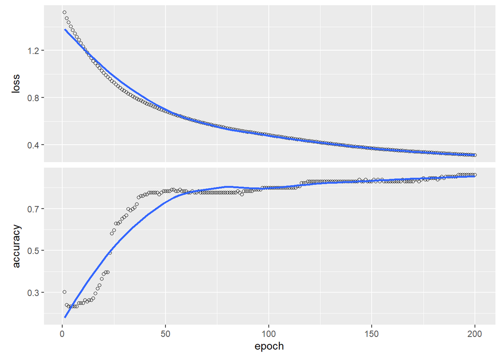

```r
history = model %>% fit(
  x = x_train, y = y_train,
  epochs           = 200,
  batch_size       = 20,
  validation_split = 0
)
plot(history)
```

# Evaluate the performance of the model

```r
perf = model %>% evaluate(x_test, y_test)
print(perf)
```

```
## $loss
## [1] 0.3040883
##
## $accuracy
## [1] 0.9047619
```

# Predict on new data

We can use the predict() and predict_classes() function for predicting soft and hard classifications respectively:

```r
model %>% predict(x_test) %>% head
```

```
##           [,1]         [,2]         [,3]
## [1,] 0.9996151 0.0003340832 5.077168e-05
## [2,] 0.9997484 0.0002266678 2.496533e-05
## [3,] 0.9971130 0.0028372859 4.969981e-05
## [4,] 0.9987524 0.0004756980 7.719736e-04
## [5,] 0.9998102 0.0001002372 8.958120e-05
## [6,] 0.9976130 0.0023005700 8.646392e-05
```

```r
model %>% predict_classes(x_test) %>% head
```

```
## [1] 0 0 0 0 0 0
```

Lastly we can visualize the confusion matrix

```r
plot_dat = nn_dat %>% filter(partition == 'test') %>%
  mutate(class_num = factor(class_num),
         y_pred    = factor(predict_classes(model, x_test)),
         Correct   = factor(ifelse(class_num == y_pred, "Yes", "No")))
plot_dat %>% select(-contains("feat")) %>% head(3)
```

```
## # A tibble: 3 x 5
##   class_num class_label partition y_pred Correct
##   <fct>     <fct>       <chr>     <fct>  <fct>
## 1 0         setosa      test      0      Yes
## 2 0         setosa      test      0      Yes
## 3 0         setosa      test      0      Yes
```

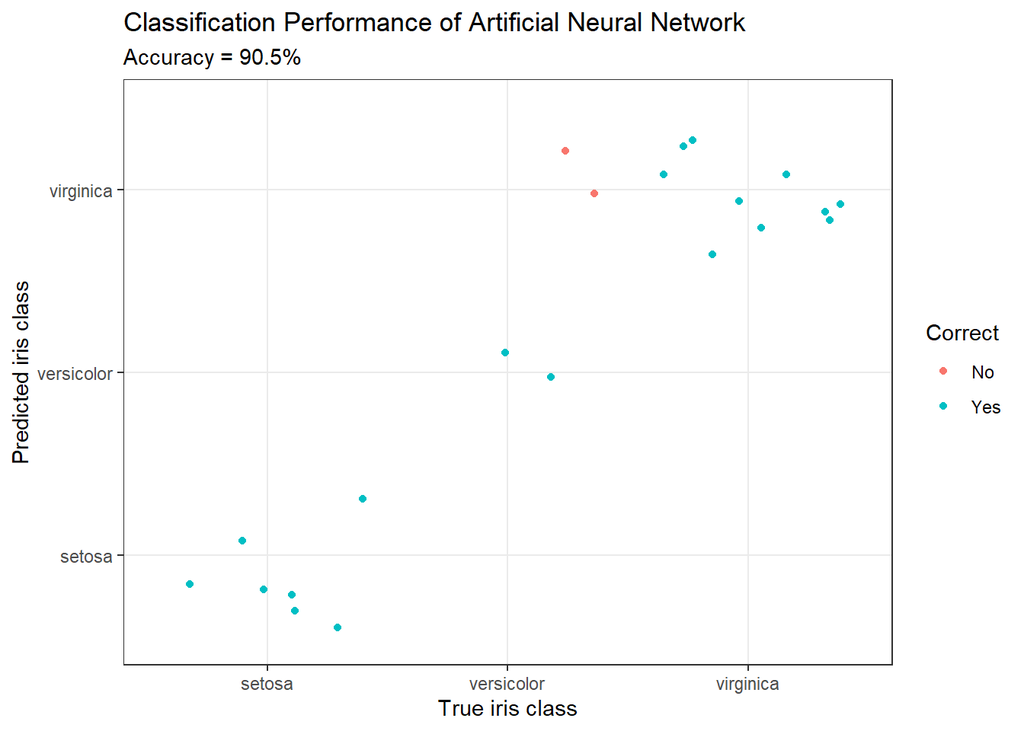

```r
title     = "Classification Performance of Artificial Neural Network"
sub_title = str_c("Accuracy = ", round(perf$acc, 3) * 100, "%")
x_lab     = "True iris class"
y_lab     = "Predicted iris class"
plot_dat %>% ggplot(aes(x = class_num, y = y_pred, colour = Correct)) +
  geom_jitter() +
  scale_x_discrete(labels = levels(nn_dat$class_label)) +
  scale_y_discrete(labels = levels(nn_dat$class_label)) +
  theme_bw() +
  labs(title = title, subtitle = sub_title, x = x_lab, y = y_lab)
```